# Confidence estimation

[Matt Jaquiery](https://github.com/mjaquiery) (matt.jaquiery@psy.ox.ac.uk)

December 2019

[Script run 2020-05-05 11:29:25]

# Introduction

Observations from [evolutionary models](https://github.com/oxacclab/EvoEgoBias) show that egocentric discounting is a successful strategy in environments where advisors cannot be clear on how advisors’ expressed confidence relates to their actual confidence. We reason that human participants may show a sensitivity to these contextual factors underlying advice-taking and respond to them in a rational manner. To test the effects of known versus unknown confidence representations, we manipulated whether participants believed advice to come from a consistent advisor or from one of a number of advisors on each trial in a judge-advisor system. Participants had two experimental blocks: in one the advice they received was always labeled as coming from a consistent individual, while in the other the advice was labeled as coming from a different advisor each time. All advice was drawn from the same distribution, which was centred on the correct answer (i.e. all of the advice was helpful on average).

After 10 trials in each block in which feedback on the correct answers was provided so participants could learn about the advisor/s, participants performed 5 trials without feedback.

We hypothesised that participants would place greater weight on the advice of the consistent advisor, presumably because they are able to learn about the calibration of the individual advisor while they cannot do likewise for the population of advisors.

# Method

The experimental code is available on [GitHub](https://github.com/oxacclab/ExploringSocialMetacognition), and the experiment can be performed by visiting [https://acclab.psy.ox.ac.uk/~mj221/ESM/ACBin/ce.html](https://acclab.psy.ox.ac.uk/~mj221/ESM/ACBin/ce.html?PROLIFIC_PID=WriteUp).

# Results

## Exclusions

```
                 SingleFirst GroupFirst
  FALSE                   15         15
  outlyingTrials           2          1
```

Our final participant list consists of 30 participants who completed an average of 27.90 trials each, of which an average of 9.90 had no feedback.

## Task performance

First we offer a characterisation of the task, to provide the reader with a sense of how the participants performed.

### Decisions

Participants offered estimates of whether various events took place before or after a given year. The correct answers were always between 1900 and 2000. Participants answered by selecting a point on one of two confidence bars, with the choice of bar indicating the chosen answer.

#### Correctness

| decision | mean | CL95.Low | CL95.High |
| --- | --- | --- | --- |
| first | .583 | .535 | .632 |
| last | .711 | .679 | .743 |
| Overall | .647 | .611 | .684 |

| decision | mean | CL95.Low | CL95.High | feedback |
| --- | --- | --- | --- | --- |
| first | .578 | .516 | .640 | TRUE |
| last | .717 | .677 | .756 | TRUE |
| Overall | .647 | .601 | .694 | TRUE |

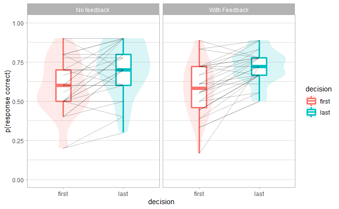

### Timing

We can look at the response time - the difference between the time the response is opened and the time the response is received.

| decision | mean | CL95.Low | CL95.High |
| --- | --- | --- | --- |
| first | 5383 | 4503 | 6262 |
| last | 1199 | 1016 | 1382 |
| Overall | 3291 | 2795 | 3787 |

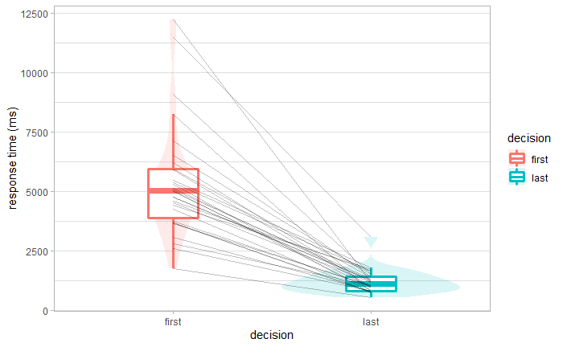

### Summary

Participants’ initial decisions were only slightly better than chance. Their final decisions were substantially better, indicating a reasonably high rate of switching from one answer to the other following advice. The time taken to answer each question was consistent with previous experiments.

## Metacognitive performance

### Confidence

Each answer bar allowed the participant to express their confidence in that answer by selecting a higher point on the bar for a higher confidence, in a range of 0-100% for each decision.

| decision | mean | CL95.Low | CL95.High |
| --- | --- | --- | --- |
| first | 55.1 | 49.4 | 60.8 |
| last | 56.4 | 50.9 | 61.9 |
| Overall | 55.8 | 50.4 | 61.1 |

| decision | mean | CL95.Low | CL95.High | feedback |
| --- | --- | --- | --- | --- |
| first | 55.333 | 49.379 | 61.288 | TRUE |
| last | 56.631 | 50.959 | 62.304 | TRUE |
| Overall | 55.982 | 50.452 | 61.513 | TRUE |

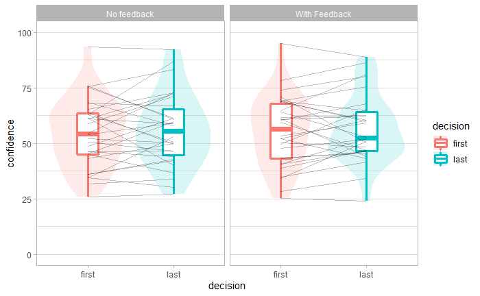

### Relationship between confidence and p(correct)

Participants indicated the confidence in their decisions simultaneously with the decisions themselves. We can thus explore how well a participant’s confidence signals their accuracy. We provide only a brief examination here where normalised responses are split into high and low confidence for each participant, and the accuracies of the two categories are compared. This is done separately for first and last decisions.

| decision | mean | CL95.Low | CL95.High |
| --- | --- | --- | --- |
| first | -.007 | -.087 | .073 |
| last | .144 | .063 | .224 |
| Overall | .068 | .015 | .122 |

```
[1] "p(correct|high confidence) - p(correct|low confidence) for initial estimates"
Bayes factor analysis
--------------
[1] Alt., r=0.707 : 0.1970142 ±0.01%

Against denominator:
  Null, mu = 0
---
Bayes factor type: BFoneSample, JZS

[1] "p(correct|high confidence) - p(correct|low confidence) for final decisions"
Bayes factor analysis
--------------
[1] Alt., r=0.707 : 33.3622 ±0%

Against denominator:
  Null, mu = 0
---
Bayes factor type: BFoneSample, JZS
```

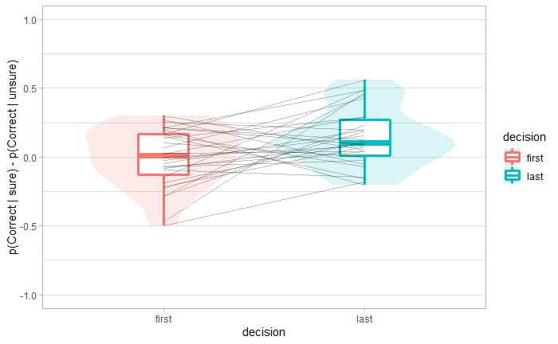

### Summary

Participants’ answers were generally around the midpoint on the scale, with a fair amount of variation between participants. Confidence in final decisions did not appear to be consistently higher than initial estimates, although this is unsurprising given the final decisions are not split by whether the advisor agreed with the initial decision.

The relationship between confidence and the probability of being correct is essentially zero for initial estimates, indicating that participants are guessing on initial decisions. Final decisions did show a relationship where higher confidence in decisions was indicative of a greater probability of being correct, presumably because participants’ confidence was readily affected by advice.

## Advisor performance

The advice offered should be equivalent between single/group advisors.

### Accuracy

| advisor0idDescription | feedback | advisorAccuracy | advisorAgree |
| --- | --- | --- | --- |
| mass | FALSE | .765 | .588 |
| mass | TRUE | .719 | .607 |
| single | FALSE | .753 | .597 |
| single | TRUE | .781 | .596 |

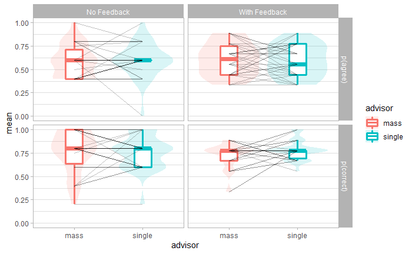

### Distance

Distance is the continuous version of agreement - the difference along the confidence scale between the advice and the initial estimate. Where different scales are endorsed, the difference is the combination of how sure the participant was on one scale plus how sure the advisor was on the other.

| advisor0idDescription | feedback | adviceDistance |
| --- | --- | --- |
| mass | FALSE | 55.2 |
| mass | TRUE | 56.8 |
| single | FALSE | 54.5 |
| single | TRUE | 59.4 |

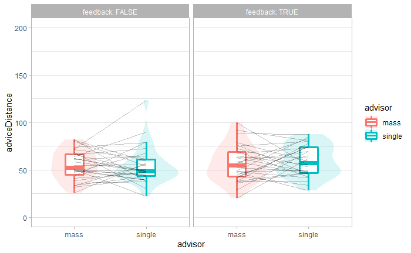

### Summary

The advisors’ performances were within the expected ranges for both the probability and extent of agreement with the participants and the objective accuracy of their advice. The advisors didn’t differ substantially from one another in any of these aspects.

### Influence

The measure of influence is the extent to which a participant’s confidence moves in the expected direction as a function of the advice (increasing when agreed with, decreasing when disagreed with).

Influence is the primary outcome measure, and is thus expected to differ between advisors and feedback conditions.

| advisor0idDescription | feedback | advisorInfluence |
| --- | --- | --- |
| mass | FALSE | 22.4 |
| mass | TRUE | 29.0 |
| single | FALSE | 21.9 |
| single | TRUE | 23.5 |

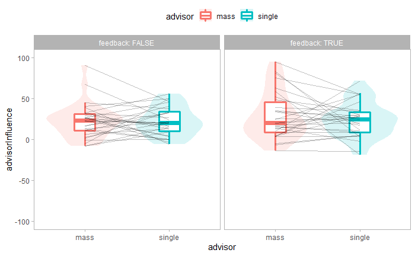

#### Influence distribution

It’s good to keep a general eye on the distribution of weight-on-advice on a trial-by-trial basis.

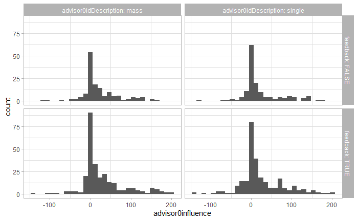

#### Is initial accuracy or initial confidence a better predictor of influence?

[output not shown]

| property | BF | estimate | statistic | p.value | parameter | conf.low | conf.high |
| --- | --- | --- | --- | --- | --- | --- | --- |
| accuracy | 8.690744 | -0.31369133 | -1.7642296 | 0.2128294 | 25.9 | -0.6096821 | 0.05670371 |
| confidence | 410.690101 | -0.04165559 | -0.2943262 | 0.5148627 | 25.9 | -0.3952083 | 0.31937403 |

## Hypothesis testing

The hypotheses being tested here are:

1. Participants will place higher weight on the advice of the single consistent advisor.

*t*(29) = -0.12, *p* = .906, *d* = 0.03, BF = 0.20; *M*|single = 21.91 [15.40, 28.42], *M*|mass = 22.42 [14.55, 30.29]

### Summary

The null model in which the advisors’ advice is the same is 5x more likely than the alternative given the data observed. It would be appropriate to conclude that this manipulation does not produce a meaningful difference in advice processing.

## Exploration

### Do people interpret lower-confidence agreement as supportive or counter?

According to a rational integration of advice, agreement, no matter how low in confidence, ought to increase one’s confidence in one’s decision. Nevertheless, when presented visually with two markers on a bar, participants may instinctively average within the bar, rather than adding the advisor’s confidence to their own. We can test these two models of behaviour in our data.

*Note:* we only plot a few graphs for an overview; we don’t need 30 of them here.

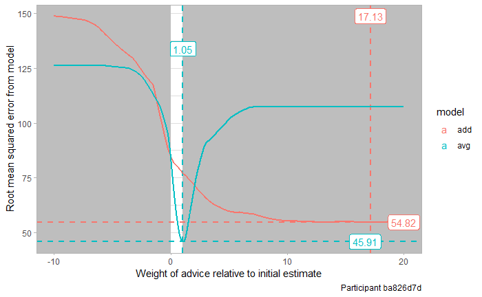

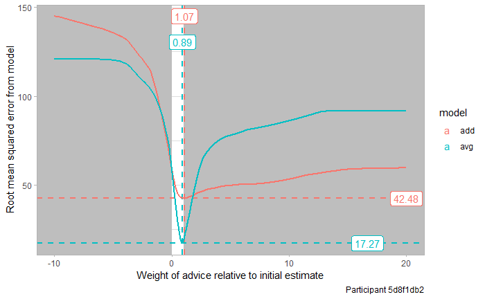

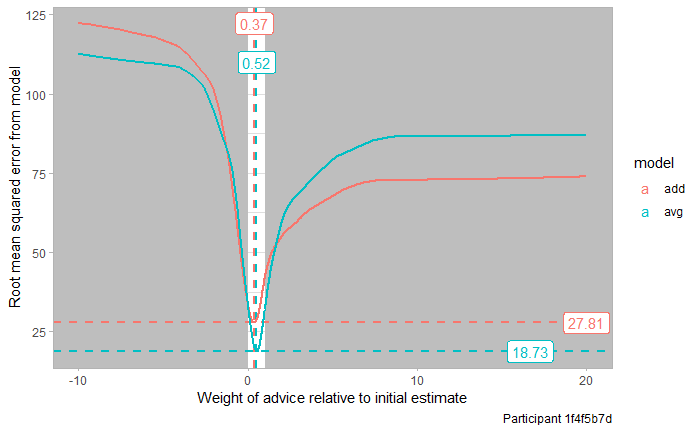

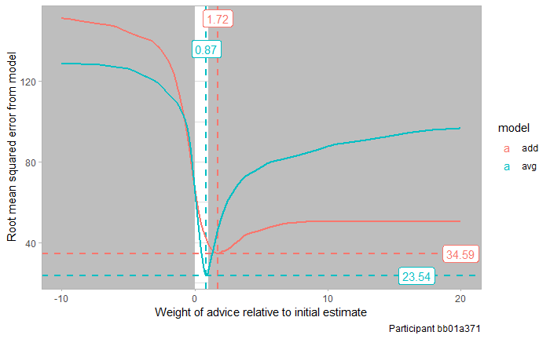

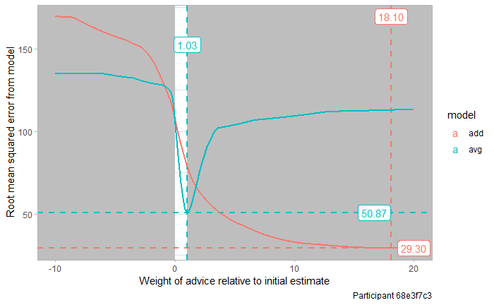

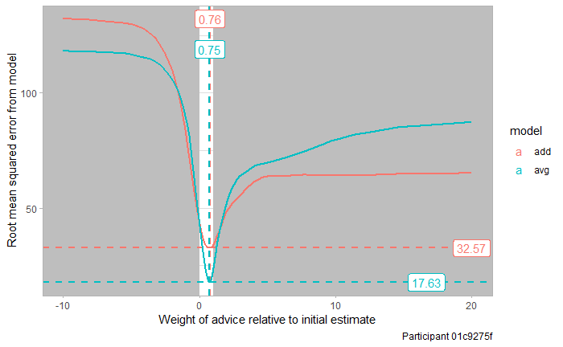

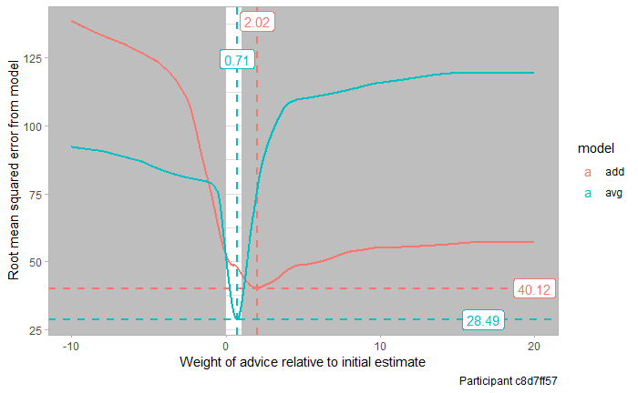

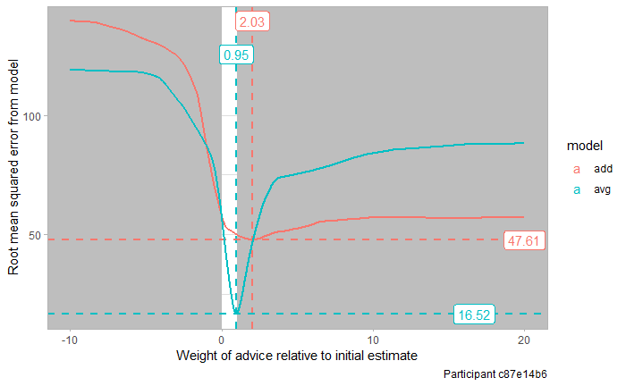

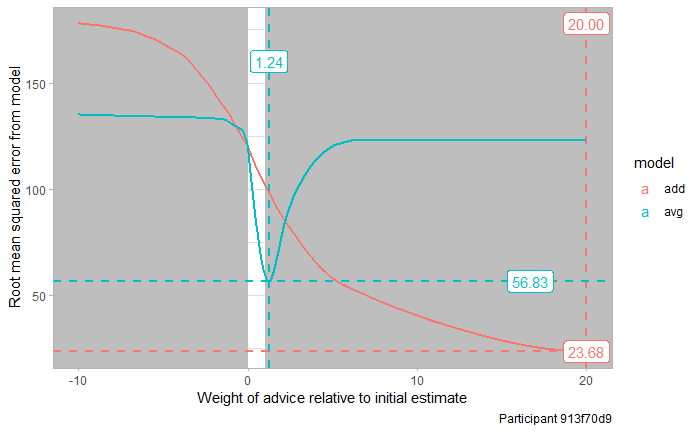

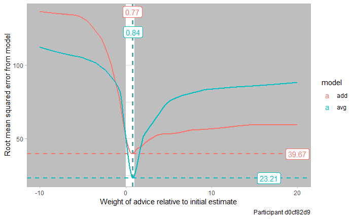

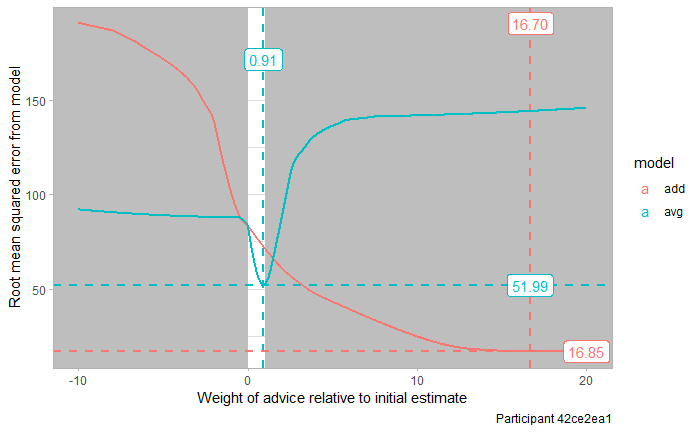

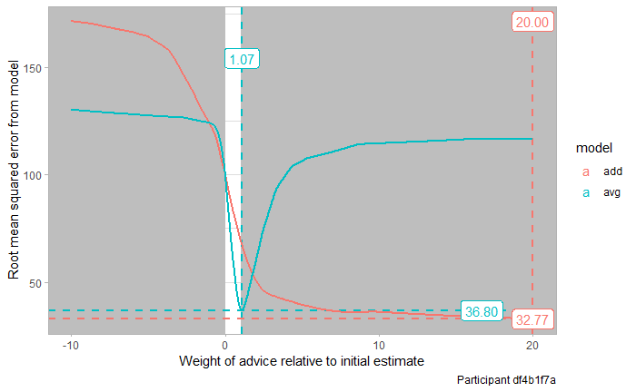

[18 more figures not shown]

| model | okx |
| --- | --- |
| add | 0.1666667 |
| avg | 0.6333333 |

| okboth | okneither | avgBest |
| --- | --- | --- |
| 0.1333333 | 0.3333333 | 0.7 |

[output not shown]

[output cut: 827 more lines]

```
attributes are not identical across measure variables;
they will be dropped
```

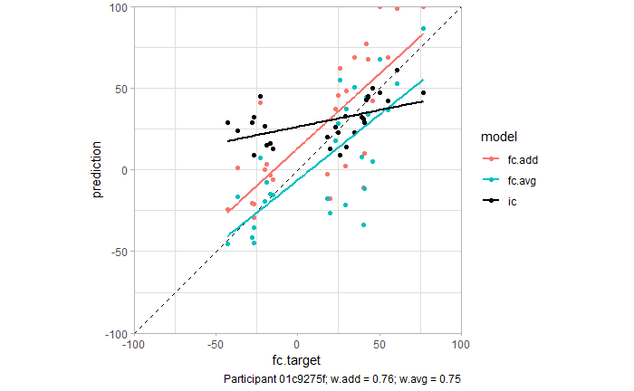

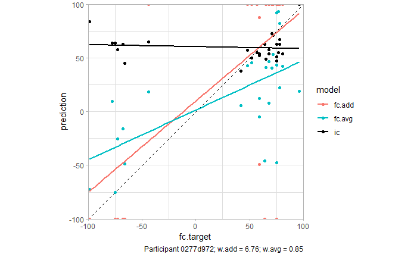

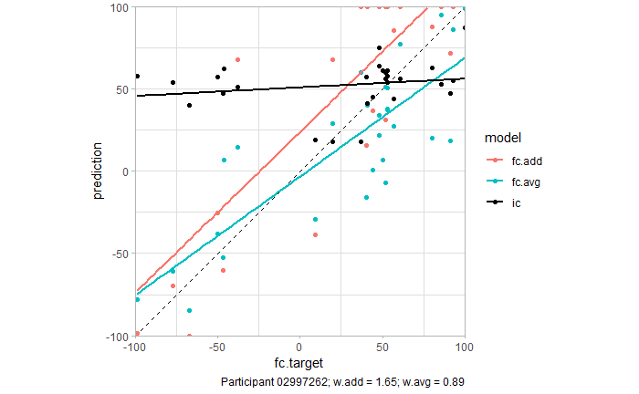

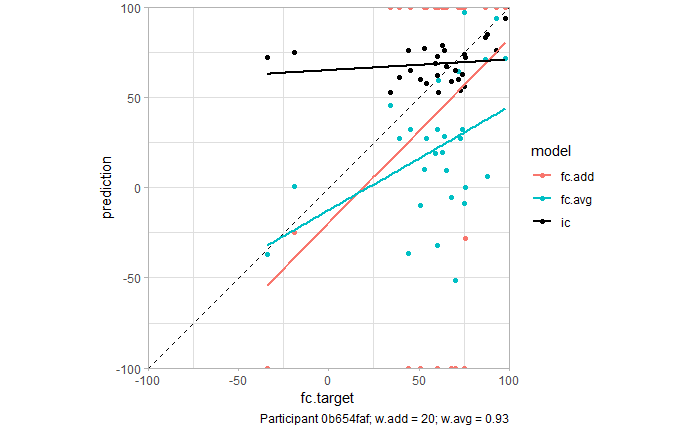

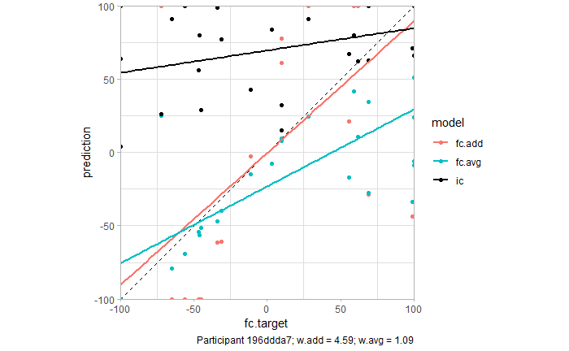

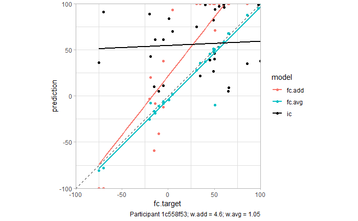

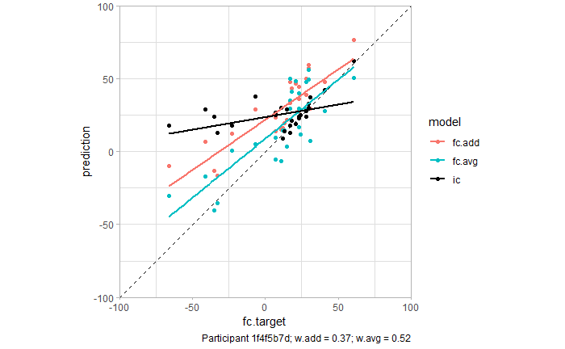

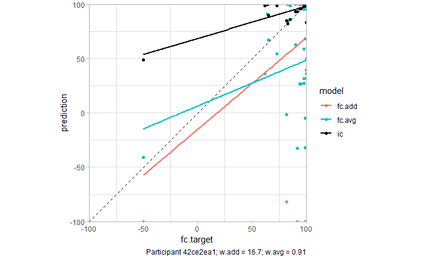